# Getting Started with didhelpers: Diagnosing Your DiD Design

## Overview

**didhelpers** provides lightweight diagnostic and visualization utilities for staggered difference-in-differences (DiD) designs. It is not a new estimator — rather, it is the companion toolkit you wish you had when setting up a staggered DiD analysis.

The package offers three core diagnostics and a convenience wrapper:

1. **Treatment timing plot** — see when each unit gets treated.
2. **Pre-trends test** — event-study regression to check the parallel trends assumption.
3. **Bacon decomposition summary** — understand which 2×2 comparisons drive your TWFE estimate.
4. **Full diagnostics report** — run everything at once.

## Setup

```r
library(didhelpers)
library(ggplot2)
```

We will use the package’s built-in simulated dataset, which has 30 units observed over 15 time periods with staggered treatment adoption across four cohorts (including a never-treated group). The true ATT is 2.0, and there are no pre-trends by construction.

```r
data("staggered_data")
head(staggered_data)
```

```
#>   unit time         cohort treat   outcome
#> 1    1    1 Cohort 1 (t=6)     0 1.5986835
#> 2    1    2 Cohort 1 (t=6)     0 0.8296751
#> 3    1    3 Cohort 1 (t=6)     0 1.2312189
#> 4    1    4 Cohort 1 (t=6)     0 1.9025292
#> 5    1    5 Cohort 1 (t=6)     0 1.5790346
#> 6    1    6 Cohort 1 (t=6)     1 3.7807810
```

```r
table(staggered_data$cohort)
```

```
#>
#>  Cohort 1 (t=6)  Cohort 2 (t=9) Cohort 3 (t=12)   Never treated
#>             120             120              90             120
```

## 1. Plot Treatment Timing

The first step in any staggered DiD analysis is understanding the treatment variation in your panel. `plot_treatment_timing()` produces a heatmap showing when each unit switches from untreated to treated:

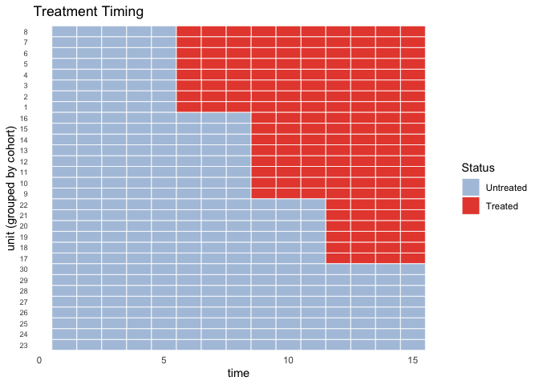

```r
plot_treatment_timing(staggered_data, unit, time, treat)
```

Units are grouped by treatment cohort on the y-axis. This makes it easy to spot the staggered adoption pattern and identify never-treated units.

## 2. Test Pre-Trends

The parallel trends assumption is central to any DiD design. `test_pretrends()` runs an event-study regression with unit and time fixed effects and returns pre-treatment lead coefficients:

```r
pt <- test_pretrends(staggered_data, unit, time, outcome, treat, n_lags = 3)
```

```
#> Wald test, H0: joint nullity of lead_3 and lead_2
#>  stat = 0.232853, p-value = 0.792378, on 2 and 400 DoF, VCOV: IID.
```

```r
pt$coefficients
```

```
#> # A tibble: 6 × 6
#>   term   estimate std_error statistic  p_value rel_time
#>   <chr>     <dbl>     <dbl>     <dbl>    <dbl>    <dbl>
#> 1 lead_3 -0.00199     0.134   -0.0149 9.88e- 1       -3
#> 2 lead_2 -0.0917      0.174   -0.528  5.98e- 1       -2
#> 3 lag_0   1.93        0.172   11.2    1.48e-25        0
#> 4 lag_1   1.95        0.175   11.1    3.51e-25        1
#> 5 lag_2   1.84        0.154   11.9    2.56e-28        2
#> 6 lag_3   1.95        0.146   13.4    4.86e-34        3
```

The joint F-test checks whether all pre-treatment coefficients are jointly zero:

```r
pt$f_test
```

```
#> $statistic
#> [1] 0.2328527
#>
#> $p_value
#> [1] 0.7923775
```

Since our simulated data has no true pre-trends, the lead coefficients should be small and statistically insignificant. The `autoplot()` method produces the classic event-study coefficient plot:

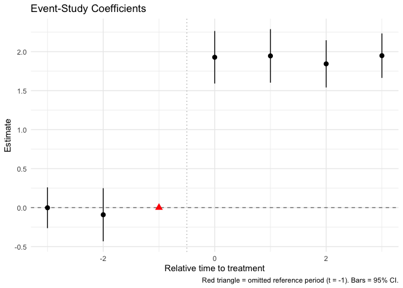

```r
autoplot(pt)
```

You can adjust the confidence level (default is 95%):

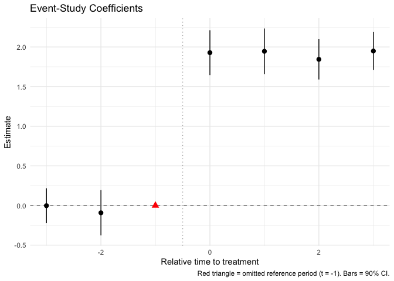

```r
autoplot(pt, conf.level = 0.90)
```

## 3. Bacon Decomposition

Goodman-Bacon (2021) showed that the two-way fixed effects (TWFE) estimator is a weighted average of all possible 2×2 DD comparisons. Some of these comparisons may use already-treated units as controls, leading to potential bias. `bacon_weight_summary()` provides a clean summary:

```r
bs <- bacon_weight_summary(staggered_data, unit, time, outcome, treat)
bs$summary
```

```
#> # A tibble: 3 × 4
#>   type                     n_comparisons total_weight weighted_avg_estimate
#>   <chr>                            <int>        <dbl>                 <dbl>
#> 1 Earlier vs Later Treated             3        0.229                  2.00
#> 2 Later vs Earlier Treated             3        0.198                  2.02
#> 3 Treated vs Untreated                 3        0.573                  1.89
```

The scatter plot shows each 2×2 comparison’s estimate against its weight, colored by comparison type:

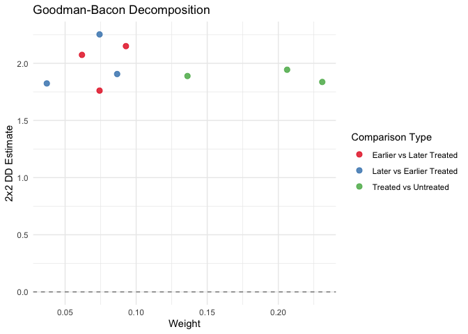

```r
autoplot(bs)
```

## 4. Full Diagnostics Report

For a quick overview, `did_diagnostics_report()` runs all three diagnostics at once:

```r
report <- did_diagnostics_report(staggered_data, unit, time, outcome, treat)
```

```
#> Wald test, H0: joint nullity of lead_3 and lead_2
#>  stat = 0.232853, p-value = 0.792378, on 2 and 400 DoF, VCOV: IID.
```

```r
report
```

```
#> ============================================================
#> DiD Diagnostics Report
#> ============================================================
#>
#> [1] Treatment timing plot: ready (access via $treatment_plot)
#>     Use plot() on this report to display all figures.
#>
#> [2] Pre-trends test
#> ----------------------------------------
#> --- Pre-Trends Event-Study Test ---
#> Leads: 2 | Lags: 4 | Obs: 450
#>
#>    Term Estimate Std.Err t value Pr(>|t|)
#>  lead_3  -0.0020  0.1335  -0.015   0.9881
#>  lead_2  -0.0917  0.1737  -0.528   0.5979
#>   lag_0   1.9283  0.1720  11.212   0.0000 ***
#>   lag_1   1.9457  0.1751  11.111   0.0000 ***
#>   lag_2   1.8439  0.1544  11.940   0.0000 ***
#>   lag_3   1.9489  0.1456  13.390   0.0000 ***
#>
#> Joint F-test of pre-treatment leads: F = 0.233, p = 0.7924
#> ---
#> Signif. codes: 0 '***' 0.001 '**' 0.01 '*' 0.05 '.' 0.1
#>
#> [3] Bacon decomposition
#> ----------------------------------------
#> --- Goodman-Bacon (2021) Decomposition ---
#> TWFE estimate: 1.9405 | 2x2 comparisons: 9
#>
#>                      Type N Weight Avg Est.
#>  Earlier vs Later Treated 3  0.229   2.0034
#>  Later vs Earlier Treated 3  0.198   2.0208
#>      Treated vs Untreated 3  0.573   1.8876
#>
#> Access $two_by_twos for all individual comparisons.
#> Use plot() or autoplot() to visualize.
#> ============================================================
```

Individual components are accessible via `report$treatment_plot`, `report$pretrends`, and `report$bacon`.

If you have the **patchwork** package installed, `plot(report)` produces a composite figure with all three diagnostics arranged together:

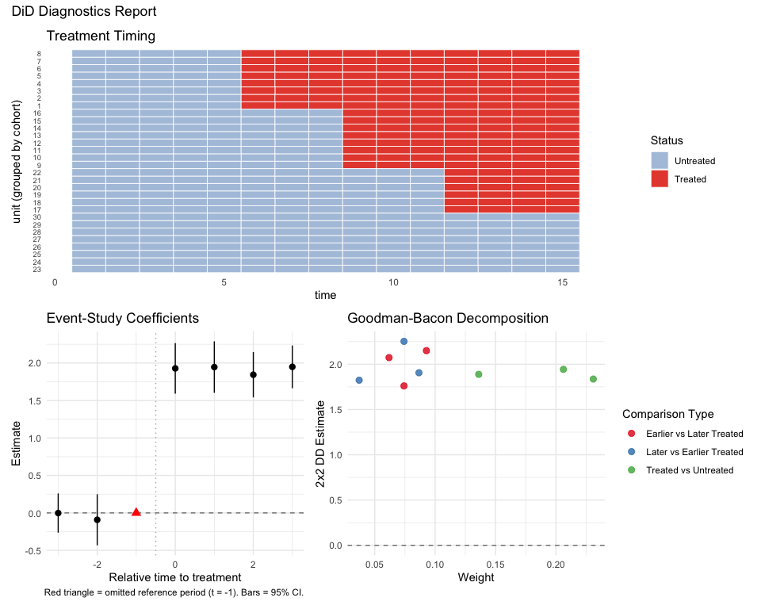

```r
plot(report)
```

## 5. Printing and Summaries

All didhelpers objects have clean `print()` and `summary()` methods modelled after the output style of **fixest**:

```r
pt
```

```
#> --- Pre-Trends Event-Study Test ---
#> Leads: 2 | Lags: 4 | Obs: 450
#>
#>    Term Estimate Std.Err t value Pr(>|t|)
#>  lead_3  -0.0020  0.1335  -0.015   0.9881
#>  lead_2  -0.0917  0.1737  -0.528   0.5979
#>   lag_0   1.9283  0.1720  11.212   0.0000 ***
#>   lag_1   1.9457  0.1751  11.111   0.0000 ***
#>   lag_2   1.8439  0.1544  11.940   0.0000 ***
#>   lag_3   1.9489  0.1456  13.390   0.0000 ***
#>
#> Joint F-test of pre-treatment leads: F = 0.233, p = 0.7924
#> ---
#> Signif. codes: 0 '***' 0.001 '**' 0.01 '*' 0.05 '.' 0.1
```

```r
bs
```

```
#> --- Goodman-Bacon (2021) Decomposition ---
#> TWFE estimate: 1.9405 | 2x2 comparisons: 9
#>
#>                      Type N Weight Avg Est.
#>  Earlier vs Later Treated 3  0.229   2.0034
#>  Later vs Earlier Treated 3  0.198   2.0208
#>      Treated vs Untreated 3  0.573   1.8876
#>
#> Access $two_by_twos for all individual comparisons.
#> Use plot() or autoplot() to visualize.
```

The `summary()` method provides additional detail (R-squared, HHI of weights):

```r
summary(pt)
```

```
#> --- Pre-Trends Event-Study Test (Summary) ---
#>
#> Observations: 450
#> R-squared: 0.9465 | Adj. R-squared: 0.9400
#>
#>    Term Estimate Std.Err t value Pr(>|t|)
#>  lead_3  -0.0020  0.1335  -0.015   0.9881
#>  lead_2  -0.0917  0.1737  -0.528   0.5979
#>   lag_0   1.9283  0.1720  11.212   0.0000 ***
#>   lag_1   1.9457  0.1751  11.111   0.0000 ***
#>   lag_2   1.8439  0.1544  11.940   0.0000 ***
#>   lag_3   1.9489  0.1456  13.390   0.0000 ***
#>
#> Joint F-test of pre-treatment leads: F = 0.233, p = 0.7924
#> ---
#> Signif. codes: 0 '***' 0.001 '**' 0.01 '*' 0.05 '.' 0.1
```

```r
summary(bs)
```

```
#> --- Goodman-Bacon Decomposition (Summary) ---
#>
#> TWFE estimate:  1.9405
#> Comparisons:    9
#> Max weight:     0.2309
#> HHI of weights: 0.1467
#>
#> By comparison type:
#>                      Type N Weight Avg Est.
#>  Earlier vs Later Treated 3  0.229   2.0034
#>  Later vs Earlier Treated 3  0.198   2.0208
#>      Treated vs Untreated 3  0.573   1.8876
```

## 6. Broom Integration

The `tidy()`, `glance()`, and `augment()` methods enable seamless integration with **modelsummary** and tidyverse workflows:

```r
tidy(pt)
```

```
#> # A tibble: 6 × 7
#>   term   estimate std.error statistic  p.value conf.low conf.high
#>   <chr>     <dbl>     <dbl>     <dbl>    <dbl>    <dbl>     <dbl>
#> 1 lead_3 -0.00199     0.134   -0.0149 9.88e- 1   -0.264     0.260
#> 2 lead_2 -0.0917      0.174   -0.528  5.98e- 1   -0.432     0.249
#> 3 lag_0   1.93        0.172   11.2    1.48e-25    1.59      2.27
#> 4 lag_1   1.95        0.175   11.1    3.51e-25    1.60      2.29
#> 5 lag_2   1.84        0.154   11.9    2.56e-28    1.54      2.15
#> 6 lag_3   1.95        0.146   13.4    4.86e-34    1.66      2.23
```

```r
glance(pt)
```

```
#> # A tibble: 1 × 7
#>    nobs r.squared adj.r.squared f_statistic f_p_value n_leads n_lags
#>   <int>     <dbl>         <dbl>       <dbl>     <dbl>   <int>  <int>
#> 1   450     0.947         0.940       0.233     0.792       2      4
```

```r
head(augment(pt))
```

```
#> # A tibble: 6 × 2
#>   .fitted .resid
#>     <dbl>  <dbl>
#> 1    4.12 -0.289
#> 2    1.16  0.444
#> 3    1.33 -0.505
#> 4    1.57 -0.337
#> 5    1.66  0.244
#> 6    1.86 -0.279
```

```r
tidy(bs, type = "summary")
```

```
#> # A tibble: 3 × 4
#>   type                     n_comparisons total_weight weighted_avg_estimate
#>   <chr>                            <int>        <dbl>                 <dbl>
#> 1 Earlier vs Later Treated             3        0.229                  2.00
#> 2 Later vs Earlier Treated             3        0.198                  2.02
#> 3 Treated vs Untreated                 3        0.573                  1.89
```

```r
glance(bs)
```

```
#> # A tibble: 1 × 4
#>   twfe_estimate n_comparisons n_types max_weight
#>           <dbl>         <int>   <int>      <dbl>
#> 1          1.94             9       3      0.231
```

See `vignette("publishing-output")` for full details on table export and figure customization.

## Input Validation

All core functions validate their inputs and return informative error messages if something is wrong:

```r
# Incorrect column name
test_pretrends(staggered_data, unit, time, outcome, wrong_col)
```

```
#> Error: Column(s) not found in `data`: wrong_col
```

```r
# Non-data-frame input
test_pretrends("not a data frame", unit, time, outcome, treat)
```

```
#> Error: `data` must be a data frame.
```

## Relationship to Other Packages

**didhelpers** is a *diagnostic companion*, not a replacement for any estimator package. Here is how it relates to the ecosystem:

[output not shown]

## Next Steps

These diagnostics help you decide whether a standard TWFE estimator is appropriate for your data. If the Bacon decomposition reveals substantial weight on problematic comparisons (e.g., already-treated as controls), or if pre-trends tests fail, consider robust estimators such as those in the [DIDmultiplegt](https://github.com/chaisemartinPackages/did_multiplegt_dyn) family of packages.